# Predicting Exercise Gestures

Nina Quiazon

1/25/2021

## Overview

In this project, we will explore which kind of prediction model will give the best result for predicting which activity or exercise is being performed based on indicators collected from the `Weight Lifting Exercise Dataset`. Complete sources of data are indicated below.

Training data: https://d396qusza40orc.cloudfront.net/predmachlearn/pml-training.csv

Test data: https://d396qusza40orc.cloudfront.net/predmachlearn/pml-testing.csv

Project Link: http://web.archive.org/web/20161224072740/http:/groupware.les.inf.puc-rio.br/har

## Data Processing

First we load the testing and the training data, and then remove columns that does not help with the prediction: columns with NA values, and columns that were used for identification (i.e., the first 7 columns).

```r
#Loading data, and treating empty cells as NA values.
training <- read.csv("pml-training.csv", na.strings = c("NA", "", " "))
test <- read.csv("pml-testing.csv", na.strings = c("NA", "", " "))

#Removing NA columns
training <- training[, colSums(is.na(training)) == 0]
test <- test[, colSums(is.na(test)) == 0]

#Removing the first 7 columns
training <- training[, -c(1:7)]
test <- test[, -c(1:7)]

#Setting classe variable as factor
training$classe <- factor(training$classe)
```

We then split the training data to set apart 30% for validation. We will use the `caret` package for this process.

```r
set.seed(7826)
library(caret)
toTrain <- createDataPartition(training$classe, p = 0.7, list = FALSE)
train <- training[toTrain, ]
cv <- training[-toTrain, ]
```

## Prediction Models

In this section, we will investigate accuracy of prediction models using two methods discussed in class, decision trees and random forests, and then choose the one that gives us the best result. We have chosen to implement only these models as one is an improvement of the other, and random forest perform as good as the other methods (bagging and boosting), if not better.

### Decision Trees

The following codes will show how the decision tree was created using the `rpart` package.

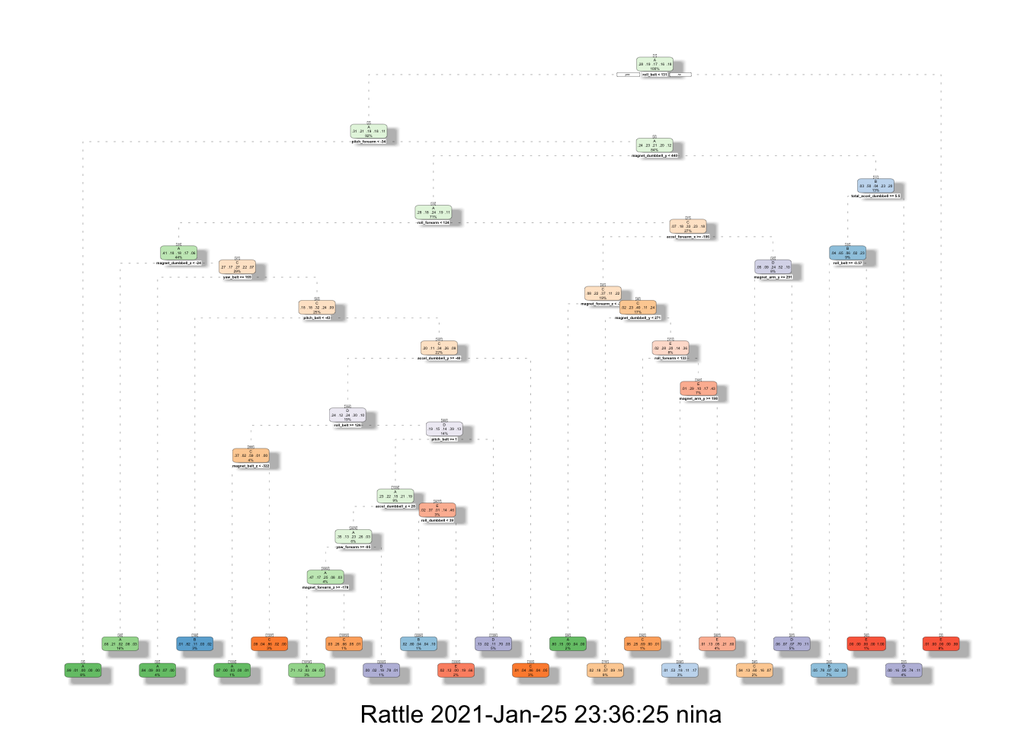

```r
library(rpart)
library(rpart.plot)
library(rattle)

#Fitting the training data in a tree model
fitTree <- rpart(classe ~ ., train, method = "class")

#Plotting the decision tree
fancyRpartPlot(fitTree)
```

```r
#Validating outcomes
predictTree <- predict(fitTree, cv, type ="class")

# Showing prediction results in validation set
(confusionTree <- confusionMatrix(predictTree, cv$classe))
```

```
## Confusion Matrix and Statistics
##
##           Reference
## Prediction    A    B    C    D    E
##          A 1512  252   21  112   34
##          B   40  624   77   45   89
##          C   41  149  840   76   84
##          D   64   66   66  655   91
##          E   17   48   22   76  784
##
## Overall Statistics
##
##                Accuracy : 0.7502
##                  95% CI : (0.7389, 0.7612)
##     No Information Rate : 0.2845
##     P-Value [Acc > NIR] : < 2.2e-16
##
##                   Kappa : 0.6825
##
##  Mcnemar's Test P-Value : < 2.2e-16
##
## Statistics by Class:
##
##                      Class: A Class: B Class: C Class: D Class: E
## Sensitivity            0.9032   0.5478   0.8187   0.6795   0.7246
## Specificity            0.9005   0.9471   0.9280   0.9417   0.9661
## Pos Pred Value         0.7830   0.7131   0.7059   0.6953   0.8279
## Neg Pred Value         0.9590   0.8972   0.9604   0.9375   0.9397
## Prevalence             0.2845   0.1935   0.1743   0.1638   0.1839
## Detection Rate         0.2569   0.1060   0.1427   0.1113   0.1332
## Detection Prevalence   0.3281   0.1487   0.2022   0.1601   0.1609
## Balanced Accuracy      0.9019   0.7475   0.8733   0.8106   0.8453
```

### Random Forests

The following code block will show how the data was fitted in a random forest model using the `randomForest` package.

```r
library(randomForest)

#Fitting the training data in a random forest
fitForest<- randomForest(classe ~ ., train, mtry = sqrt(dim(train)[2]-1), importance =TRUE)

#Validating outcomes
predictForest <- predict(fitForest, newdata = cv)

# Showing prediction results in validation set
(confusionForest <- confusionMatrix(predictForest, cv$classe))
```

```
## Confusion Matrix and Statistics
##
##           Reference
## Prediction    A    B    C    D    E
##          A 1670    3    0    0    0
##          B    3 1136    8    0    0
##          C    0    0 1017   13    0
##          D    0    0    1  950    6
##          E    1    0    0    1 1076
##
## Overall Statistics
##
##                Accuracy : 0.9939
##                  95% CI : (0.9915, 0.9957)
##     No Information Rate : 0.2845
##     P-Value [Acc > NIR] : < 2.2e-16
##
##                   Kappa : 0.9923
##
##  Mcnemar's Test P-Value : NA
##
## Statistics by Class:
##
##                      Class: A Class: B Class: C Class: D Class: E
## Sensitivity            0.9976   0.9974   0.9912   0.9855   0.9945
## Specificity            0.9993   0.9977   0.9973   0.9986   0.9996
## Pos Pred Value         0.9982   0.9904   0.9874   0.9927   0.9981
## Neg Pred Value         0.9991   0.9994   0.9981   0.9972   0.9988
## Prevalence             0.2845   0.1935   0.1743   0.1638   0.1839
## Detection Rate         0.2838   0.1930   0.1728   0.1614   0.1828
## Detection Prevalence   0.2843   0.1949   0.1750   0.1626   0.1832
## Balanced Accuracy      0.9984   0.9975   0.9943   0.9920   0.9970
```

## Conclusion

We acquired an accuracy of *75.02%* using decision trees, while we had *99.39%* accuracy with random forests. For this data, we found out that random forest fits our data better.

## Prediction

We will now use our random forest model to predict `classe` in our test set in the code block below.

```r
(predict(fitForest, test))
```

```
##  1  2  3  4  5  6  7  8  9 10 11 12 13 14 15 16 17 18 19 20
##  B  A  B  A  A  E  D  B  A  A  B  C  B  A  E  E  A  B  B  B
## Levels: A B C D E
```